# ASAP invitro cell cultures + treatments. Differential expression analysis of genes.

Raquel Garza

Before we start, I load libraries and define some helper functions to visualize the effect as a mean plot (credits to Per Brattås! who wrote the original code for it)

```r
## getSignName ##
# Get significantly different gene names.
# Taken from source code of the package deseqAbstraction which is no longer available on github.
# Credits to Per L. Brattås
# Parameters:
# x = results object from deseq
# p = padj threshold for significance
# l = log2FC threshold for significance
getSignName <- function(x,p,l=0) {
  up <- x[!is.na(x$padj) & x$padj < p & x$log2FoldChange > l,]
  down <- x[!is.na(x$padj) & x$padj < p & x$log2FoldChange < -l,]
  return(list(up=rownames(up),down=rownames(down)))
}
## getAverage ##
# Get average expression (normalized by median of ratios) of each of the conditions in a deseq object.
# Taken from source code of the package deseqAbstraction which is no longer available on github.
# Credits to Per L. Brattås
# Parameters:
# dds = deseq object
getAverage <- function(dds) {
  baseMeanPerLvl <- sapply( levels(dds$condition), function(lvl) rowMeans( counts(dds,normalized=TRUE)[,dds$condition == lvl] ) )
  baseSDPerLvl <- sapply( levels(dds$condition), function(lvl) apply( counts(dds,normalized=TRUE)[,dds$condition == lvl],1,sd ) )
  colnames(baseSDPerLvl) <- paste("st.dev:",colnames(baseSDPerLvl),sep="")
  return(list(Mean=baseMeanPerLvl,SD=baseSDPerLvl))
}

meanPlot_cus <- function(exp,test,c1 = "condition 1",c2 = "condition 2",p=.05,l=0,id=F, ttl="",
                         repel=TRUE, col1="tomato", col2="darkturquoise", col3="grey", highlights=NA){
  sign <- getSignName(x = test,p = p,l = l)
  u <- sign$up
  d <- sign$down

  #color up and down sign..
  colVec <- ifelse(test = (rownames(exp) %in% u),
                   yes = col1,
                   no = ifelse(test = (rownames(exp) %in% d),
                               yes = col2, no =col3))
  colVec[is.na(colVec)] <- "steelblue" ## if NA make sure it's not counted as <p
  #size of points
  cexVec <- ifelse(test = (rownames(exp) %in% u),
                   yes = 0.35,
                   no = ifelse(test = (rownames(exp) %in% d),
                               yes = 0.35, no = 0.3))

  exp_log <- as.data.frame(log2(exp[,c(c1, c2)] + 0.5))
  exp_log$Name <- rownames(exp_log)

  exp_log$reg <- factor(ifelse(exp_log$Name %in% u, paste('upregulated in ', c1, ' (', length(u), ')', sep =''),
                               ifelse(exp_log$Name %in% d, paste('downregulated in ', c1,' (', length(d), ')', sep =''), paste('not significant', ' (', (nrow(test) - length(u) - length(d)), ')', sep=''))))

  library(ggrepel)
  if(repel == TRUE){
    plt <- ggplot(exp_log, aes(x=get(c2), y=get(c1), label=Name, color=reg)) + geom_point(aes(size=cexVec), alpha=0.7)+ scale_color_manual(values=c(col2, col3, col1))+ scale_size_continuous(range=c(1,2), guide="none")+ geom_text_repel(data = subset(exp_log, Name %in% u | Name %in% d),direction    = "y", nudge_y = 0.4, nudge_x = -0.5)
  }else{
    plt <- ggplot(exp_log, aes(x=get(c2), y=get(c1), color=reg)) + geom_point(aes(size=cexVec), alpha=0.7)+ scale_color_manual(values=c(col2, col3, col1))+ scale_size_continuous(range=c(1,2), guide="none")
  }
  plt <- plt + labs(x=paste("log2(mean ",c2,")",sep=""),
                    y=paste("log2(mean ",c1,")",sep=""),
                    title=paste(ttl, paste(c1," vs. ",c2,sep=""), sep = ': '),
                    subtitle=paste("p-adj < ",p,", log2(fc) > ",l,sep=""))+ theme_bw() +
    theme( plot.title = element_text( size=14, face="bold"), text = element_text(size=15), panel.grid.minor = element_blank(), panel.grid.major = element_blank(), legend.title=element_blank())


  if(id==T) {
    identify(log2(exp[,1]),log2(exp[,2]),labels = rownames(exp))
  }

  if(!all(is.na(highlights))){
    plt <- plt + geom_text_repel(data = exp_log[highlights,], aes(label=Name), size = 3, segment.size= 0.1, max.overlaps = 100, color = "black") #+
      #geom_point(data=exp_log[highlights,], aes(x=get(c2), y=get(c1)), colour="springgreen3", size=5, shape=1, stroke=2)
  }
  return(plt)

}
```

## Loading gene count matrices

```r
library(data.table)
library(ggplot2)
library(ggpubr)
library(stringr)
library(DESeq2)
library(openxlsx)
library(tidyverse)
library(EnhancedVolcano)
library(bedr)
library(clusterProfiler)
library(org.Hs.eg.db)
library(pheatmap)
library(dplyr)
library(UpSetR)

# Gene name annotation
gene_annotation <- fread("/Volumes/MyPassport/annotations/human/gencode/v38/gencode.v38.annotation.gene_names.tab", data.table = F, skip=1, header = F)
colnames(gene_annotation) <- c("Geneid", "gene_name", "gene_type")

# Samplesheet / metadata
samplesheet <- fread("/Volumes/MyPassport/ASAP/code/ASAP_invitro/original/samplesheet.tab", data.table = F, header = T)
samplesheet_list <- split(samplesheet, f = list(samplesheet$celltype, samplesheet$cellline, samplesheet$condition))
samplesheet_list <- samplesheet_list[sapply(samplesheet_list, nrow) > 0]

# Split samplesheet per cell lines and treatments
celltypes <- unique(sapply(str_split(names(samplesheet_list), "[[.]]"), `[[`, 1))
for(celltype in celltypes){
  treatments_celltype <- names(samplesheet_list)[grepl(celltype, names(samplesheet_list))]
  celllines <- unique(sapply(str_split(treatments_celltype, "[[.]]"), `[[`, 2))
  for(cellline in celllines){
    celllines_treatments_celltype <- names(samplesheet_list)[grepl(celltype, names(samplesheet_list)) & grepl(cellline, names(samplesheet_list))]
    celllines_treatments_celltype <- celllines_treatments_celltype[!grepl("ctrl", celllines_treatments_celltype)]
    for(treatment in celllines_treatments_celltype){
      corresponding_ctrl <- paste(celltype, cellline, "ctrl", sep=".")
      samplesheet_list[[treatment]] = rbind(samplesheet_list[[treatment]], samplesheet_list[[corresponding_ctrl]])
    }
    samplesheet_list[[corresponding_ctrl]] = NULL
  }
}

# Read gene count matrices
# write.xlsx(samplesheet_list, "/Volumes/MyPassport/ASAP_invitro/results/tables/samplesheet_comparisons.xlsx")
path <- "/Volumes/MyPassport/ASAP/code/ASAP_invitro/original/gene_counts/unique/"
# samples <- samplesheet$samples
samples <- unique(do.call(rbind, samplesheet_list))$sample
for(i in 1:length(samples)){
  sample <- samples[i]
  if(i == 1){
    gene_counts <- fread(paste(path, sample, "_gene_count_matrix_2.csv", sep=""), data.table = F)
    colnames(gene_counts)[ncol(gene_counts)] <- sample
    rownames(gene_counts) <- gene_counts$Geneid
    row_order <- rownames(gene_counts)
  }else{
    tmp <- fread(paste(path, sample, "_gene_count_matrix_2.csv", sep=""), data.table = F)
    colnames(tmp)[ncol(tmp)] <- sample
    rownames(tmp) <- tmp$Geneid
    gene_counts <- cbind(gene_counts[row_order,], tmp[row_order,sample,drop=F])
  }
}
```

## Cell type markers

Normalization using sizeFactors calculated with all samples.

```r
samplesheet <- samplesheet[which(samplesheet$sample != "ASAP_PolyIC_Rep2_bulkRNA_vMBneurons_RC17_day52_S26"),] # Outlier in PCA and markers
samplesheet_list$neurons.RC17.PolyIC <- samplesheet_list$neurons.RC17.PolyIC[which(samplesheet_list$neurons.RC17.PolyIC$sample != "ASAP_PolyIC_Rep2_bulkRNA_vMBneurons_RC17_day52_S26"),] # Outlier in PCA and markers

rownames(samplesheet) <- samplesheet$sample
rownames(gene_counts) <- (gene_counts$Geneid)
# Differential gene expression analysis
gene_dds <- DESeqDataSetFromMatrix(gene_counts[,rownames(samplesheet)], samplesheet, design =  ~ condition)
gene_dds$condition <- relevel(gene_dds$condition, "ctrl")
gene_dds <- DESeq(gene_dds)
```

```
## -- replacing outliers and refitting for 63 genes
## -- DESeq argument 'minReplicatesForReplace' = 7
## -- original counts are preserved in counts(dds)
```

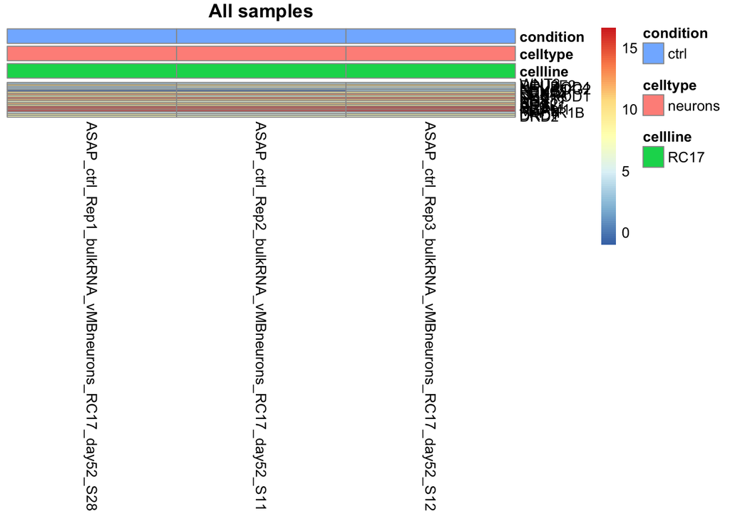

```r
# Size factors for TE normalization
# write.table(as.data.frame(gene_dds$sizeFactor), file = "/Volumes/MyPassport/ASAP_invitro/results/tables/gene_sizeFactors.tab", quote = F, sep="\t", col.names = F)

# Normalized counts to plot markers
gene_count_norm <- counts(gene_dds, normalized=T)
neuronal_genes <- c("WNT3", "POU3F2", "NEUROD4", "NEUROG2", "FOXG1", "FOXA2", "LMX1A", "NEUROD1", "SOX11", "NES", "SOX1", "SOX2", "ASCL1", "DCX", "NCAM1", "MAP2", "PPP1R1B", "DRD1", "DRD2")
samplesheet <- samplesheet[order(samplesheet$cellline, samplesheet$celltype),]
samplesheet_rc17_neurons_ctrl <- samplesheet[which(samplesheet$celltype == "neurons" & samplesheet$condition == "ctrl" & samplesheet$cellline == "RC17"),]

pheatmap(log2(gene_count_norm[neuronal_genes,rownames(samplesheet_rc17_neurons_ctrl)]+0.5), cluster_cols = F, cluster_rows = F, scale = "none", main = "All samples", annotation_col = samplesheet[,c("cellline", "celltype", "condition")])
```

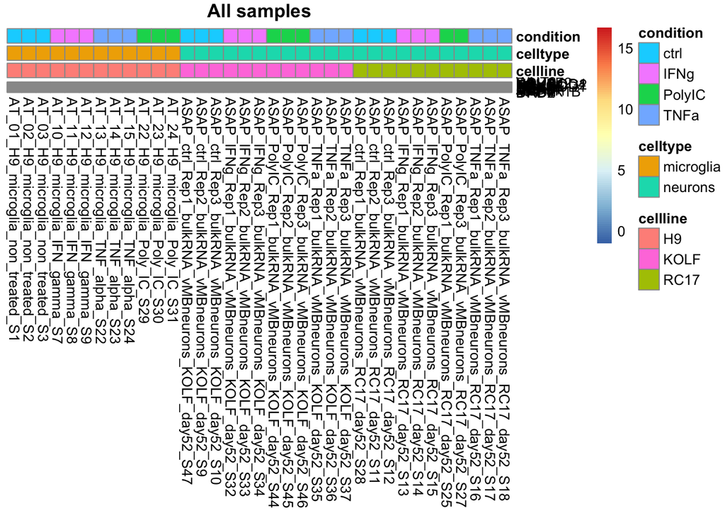

```r
pheatmap(log2(gene_count_norm[neuronal_genes,rownames(samplesheet)]+0.5), cluster_cols = F, cluster_rows = F, scale = "none", main = "All samples", annotation_col = samplesheet[,c("cellline", "celltype", "condition")])
```

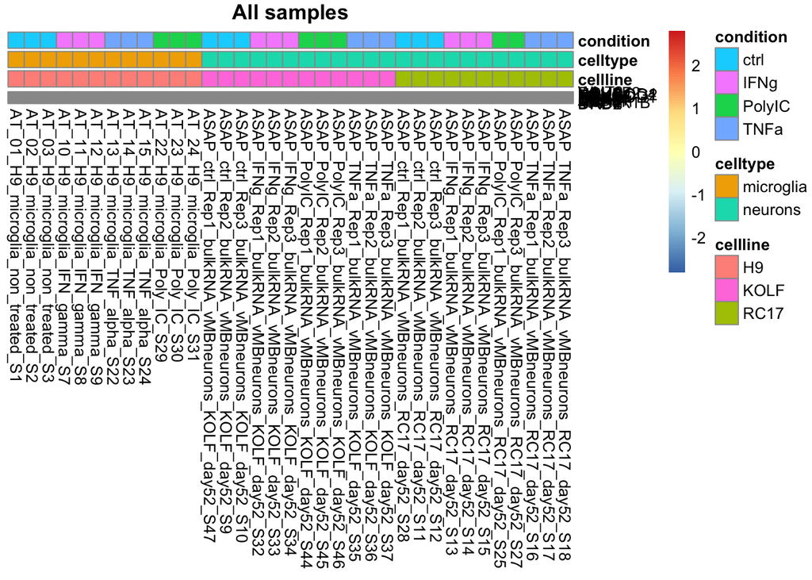

```r
pheatmap(log2(gene_count_norm[neuronal_genes,rownames(samplesheet)]+0.5), cluster_cols = F, cluster_rows = F, scale = "row", main = "All samples", annotation_col = samplesheet[,c("cellline", "celltype", "condition")])
```

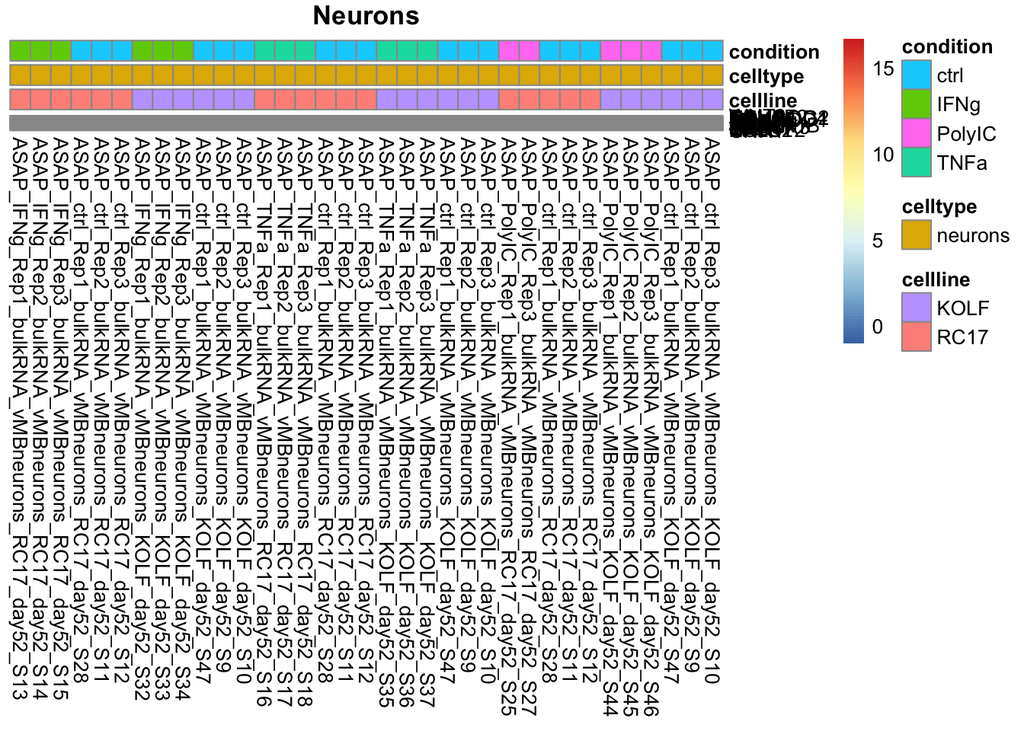

```r
# Subset just the neuron samples
neuron_samples <- c(samplesheet_list$neurons.RC17.IFNg$sample,
                    samplesheet_list$neurons.KOLF.IFNg$sample,
                    samplesheet_list$neurons.RC17.TNFa$sample,
                    samplesheet_list$neurons.KOLF.TNFa$sample,
                    samplesheet_list$neurons.RC17.PolyIC$sample,
                    samplesheet_list$neurons.KOLF.PolyIC$sample)
rownames(samplesheet) <- samplesheet$sample

pheatmap(log2(gene_count_norm[c(neuronal_genes, "RBFOX3", "PGP", "GRIN1", "GAD1", "TH", "HS3ST2", "CALB2", "CNR1"),neuron_samples]+0.5),
         cluster_cols = F, cluster_rows = F, scale = "none",
         main = "Neurons", annotation_col = samplesheet[neuron_samples,c("cellline", "celltype", "condition")])
```

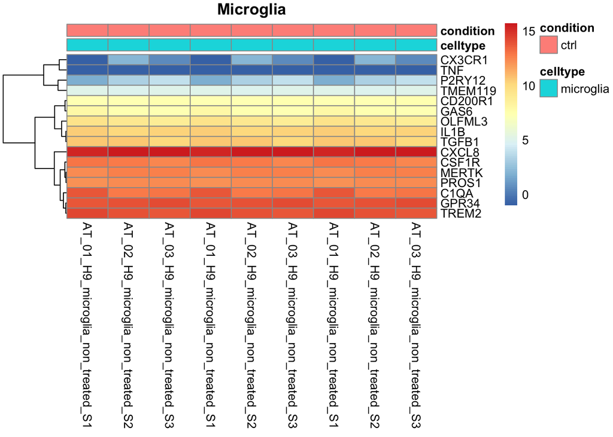

```r
# Subset just the microglia samples
microglia_samples <- c(samplesheet_list$microglia.H9.IFNg$sample,
                    samplesheet_list$microglia.H9.TNFa$sample,
                    samplesheet_list$microglia.H9.PolyIC$sample)
microglia_samples <- microglia_samples[which(grepl("non_treated", microglia_samples))]

microglial_genes <- c("C1QA", "CD200R1", "CSF1R", "CX3CR1", "GAS6", "GPR34", "IL1B", "CXCL8", "MERTK", "OLFML3", "P2RY12", "PROS1", "TGFB1", "TMEM119", "TNF", "TREM2")
pheatmap(log2(gene_count_norm[c(microglial_genes),microglia_samples]+0.5),
         cluster_cols = F, cluster_rows = T, scale = "none",
         main = "Microglia", annotation_col = samplesheet[microglia_samples,c("celltype", "condition")])
```

## Gene Differential Expression Analysis (DEA)

Looped per experiment

```r
gene_dds_list <- list()
gene_res_list <- list()
gene_res_list_df <- list()
gene_exp_list <- list()
gene_vst_list <- list()
rownames(gene_counts) <- gene_counts$Geneid

for(i in names(samplesheet_list)){
  rownames(samplesheet_list[[i]]) <- samplesheet_list[[i]]$sample
  print(i)
  conditions <- unique(samplesheet_list[[i]]$condition)
  print(c("Conditions: ", conditions))

  effect <- conditions[which(conditions != "ctrl")]
  test <- paste("condition_", effect ,"_vs_ctrl", sep = "")
  print(c("Test: ", test))
  counts <- gene_counts[,rownames(samplesheet_list[[i]])]
  gene_dds_list[[i]] <- DESeqDataSetFromMatrix(counts, samplesheet_list[[i]], design =  ~ condition)
  gene_dds_list[[i]]$condition <- relevel(gene_dds_list[[i]]$condition, "ctrl")
  gene_dds_list[[i]] <- DESeq(gene_dds_list[[i]])
  gene_res_list[[i]] <- lfcShrink(gene_dds_list[[i]], test)
  gene_exp_list[[i]] <- getAverage(gene_dds_list[[i]])
  gene_res_list_df[[i]] <- as.data.frame(gene_res_list[[i]])
  gene_res_list_df[[i]]$gene_name <- rownames(gene_res_list_df[[i]])
  gene_vst_list[[i]] <- varianceStabilizingTransformation(gene_dds_list[[i]])
}
```

```
## [1] "microglia.H9.IFNg"
## [1] "Conditions: " "IFNg"         "ctrl"
## [1] "Test: "                 "condition_IFNg_vs_ctrl"
```

[output not shown]

```
## [1] "neurons.KOLF.IFNg"
## [1] "Conditions: " "IFNg"         "ctrl"
## [1] "Test: "                 "condition_IFNg_vs_ctrl"
```

[output not shown]

```
## [1] "neurons.RC17.IFNg"
## [1] "Conditions: " "IFNg"         "ctrl"
## [1] "Test: "                 "condition_IFNg_vs_ctrl"
```

[output not shown]

```
## [1] "microglia.H9.PolyIC"
## [1] "Conditions: " "PolyIC"       "ctrl"
## [1] "Test: "                   "condition_PolyIC_vs_ctrl"
```

[output not shown]

```
## [1] "neurons.KOLF.PolyIC"
## [1] "Conditions: " "PolyIC"       "ctrl"
## [1] "Test: "                   "condition_PolyIC_vs_ctrl"
```

[output not shown]

```
## [1] "neurons.RC17.PolyIC"
## [1] "Conditions: " "PolyIC"       "ctrl"
## [1] "Test: "                   "condition_PolyIC_vs_ctrl"
```

[output not shown]

```
## [1] "microglia.H9.TNFa"
## [1] "Conditions: " "TNFa"         "ctrl"
## [1] "Test: "                 "condition_TNFa_vs_ctrl"
```

[output not shown]

```
## [1] "neurons.KOLF.TNFa"
## [1] "Conditions: " "TNFa"         "ctrl"
## [1] "Test: "                 "condition_TNFa_vs_ctrl"
```

[output not shown]

```
## [1] "neurons.RC17.TNFa"
## [1] "Conditions: " "TNFa"         "ctrl"
## [1] "Test: "                 "condition_TNFa_vs_ctrl"
```

[output not shown]

## PCA plots

All together (first 3) coloured by condition, cell type, and cell line. One per experiment, coloured by condition in each experiment.

```
## using ntop=500 top features by variance
```

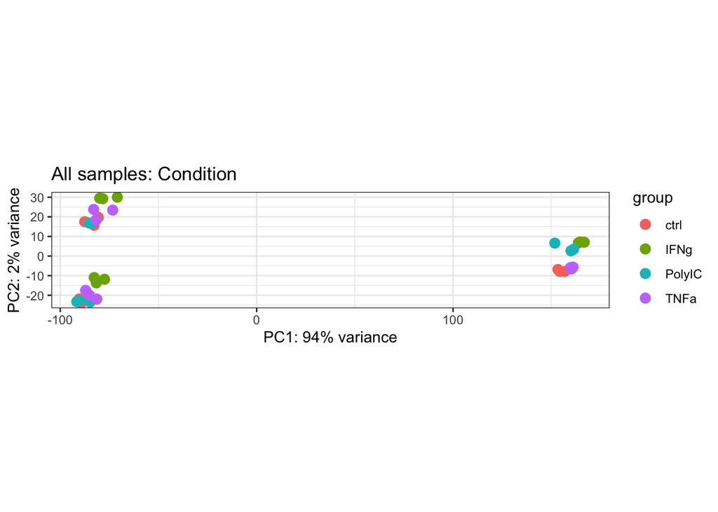

```r
gene_vst <- varianceStabilizingTransformation(gene_dds)
# PCA plots
plotPCA(gene_vst, intgroup="condition") + ggtitle("All samples: Condition") + theme_bw()
```

```
## using ntop=500 top features by variance
```

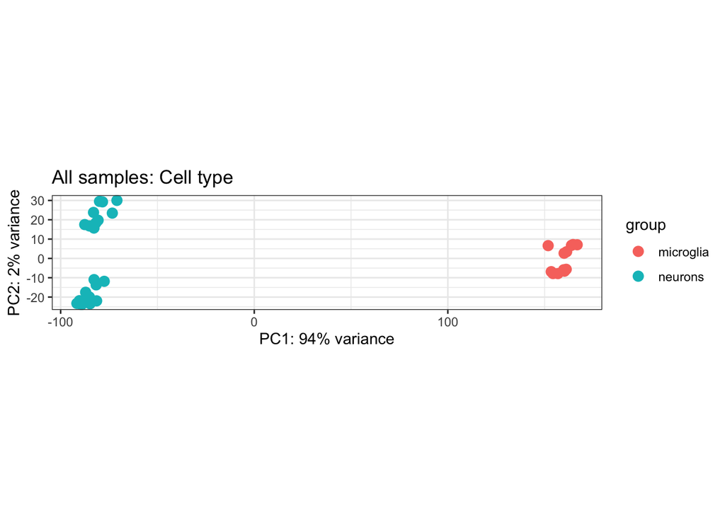

```r
plotPCA(gene_vst, intgroup="celltype") + ggtitle("All samples: Cell type") + theme_bw()
```

```
## using ntop=500 top features by variance
```

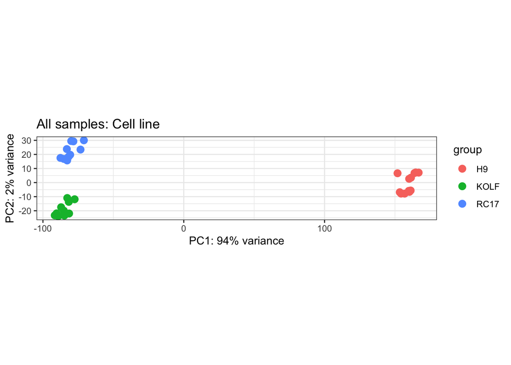

```r
plotPCA(gene_vst, intgroup="cellline") + ggtitle("All samples: Cell line") + theme_bw()
```

```
## using ntop=500 top features by variance
```

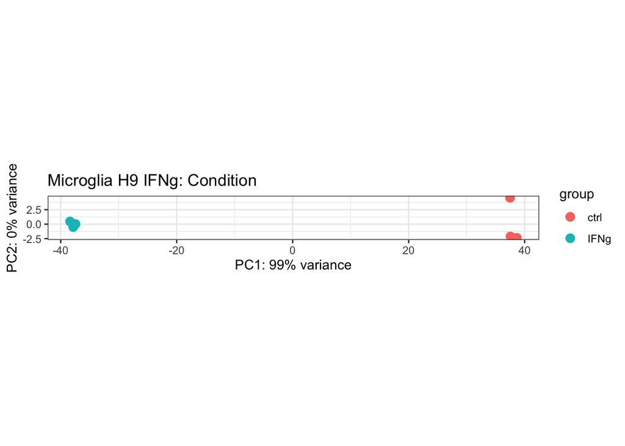

```r
plotPCA(gene_vst_list$microglia.H9.IFNg, intgroup="condition") + ggtitle("Microglia H9 IFNg: Condition") + theme_bw()
```

```
## using ntop=500 top features by variance
```

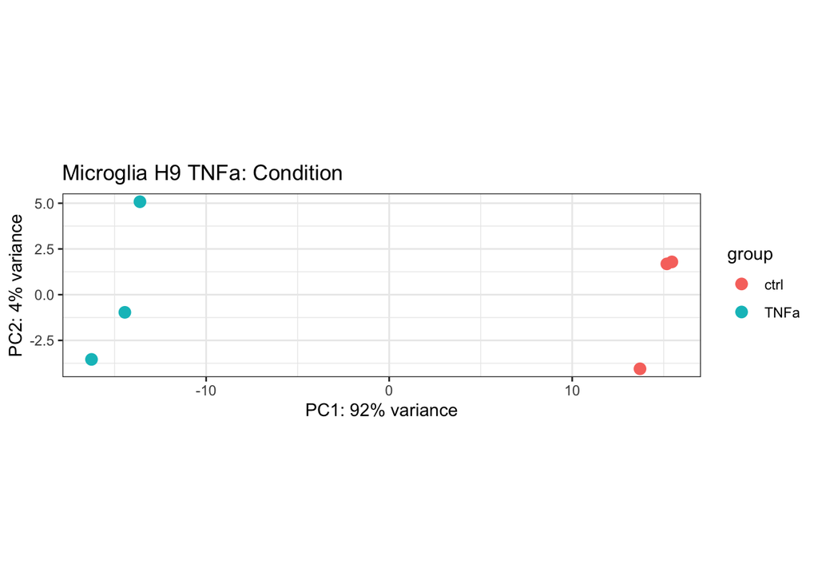

```r
plotPCA(gene_vst_list$microglia.H9.TNFa, intgroup="condition") + ggtitle("Microglia H9 TNFa: Condition") + theme_bw()
```

```
## using ntop=500 top features by variance
```

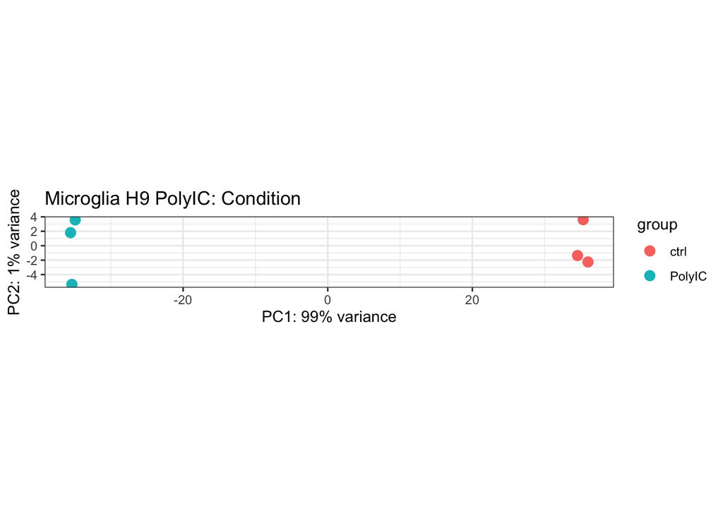

```r
plotPCA(gene_vst_list$microglia.H9.PolyIC, intgroup="condition") + ggtitle("Microglia H9 PolyIC: Condition") + theme_bw()
```

```
## using ntop=500 top features by variance
```

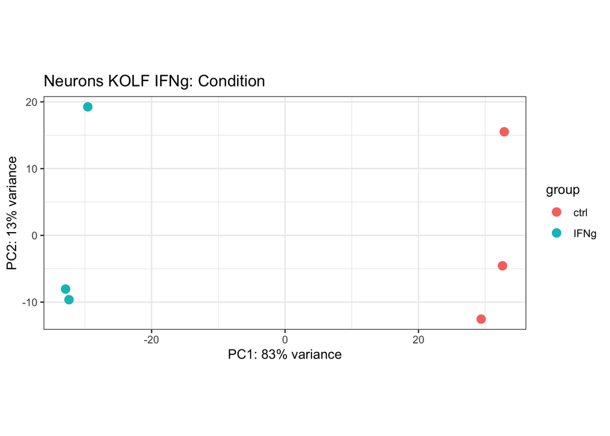

```r
plotPCA(gene_vst_list$neurons.KOLF.IFNg, intgroup="condition") + ggtitle("Neurons KOLF IFNg: Condition") + theme_bw()
```

```
## using ntop=500 top features by variance
```

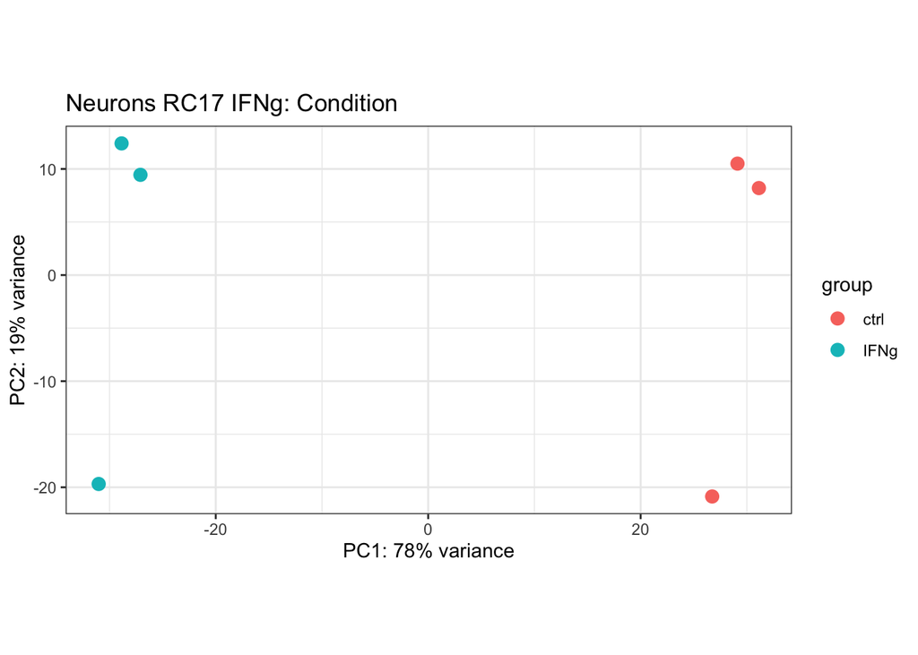

```r
plotPCA(gene_vst_list$neurons.RC17.IFNg, intgroup="condition") + ggtitle("Neurons RC17 IFNg: Condition") + theme_bw()
```

```
## using ntop=500 top features by variance
```

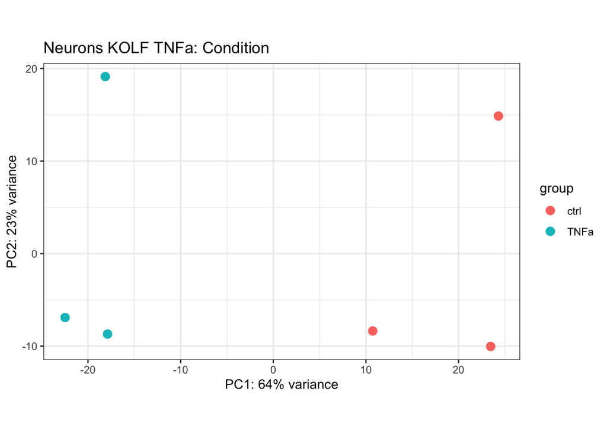

```r
plotPCA(gene_vst_list$neurons.KOLF.TNFa, intgroup="condition") + ggtitle("Neurons KOLF TNFa: Condition") + theme_bw()
```

```
## using ntop=500 top features by variance
```

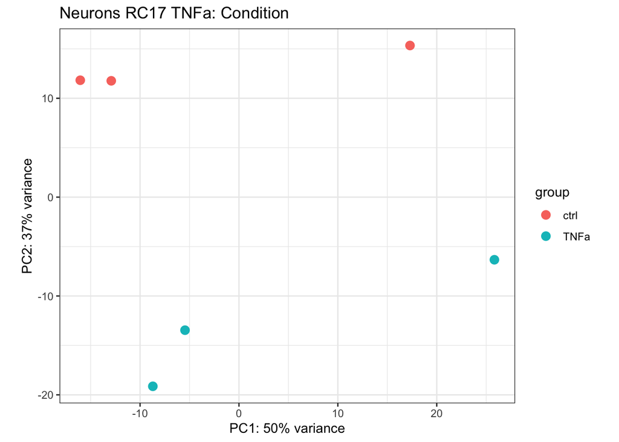

```r
plotPCA(gene_vst_list$neurons.RC17.TNFa, intgroup="condition") + ggtitle("Neurons RC17 TNFa: Condition") + theme_bw()
```

```
## using ntop=500 top features by variance
```

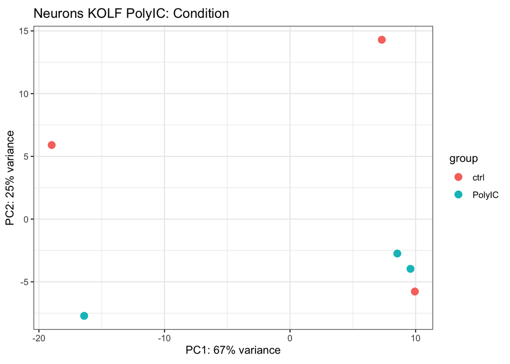

```r
plotPCA(gene_vst_list$neurons.KOLF.PolyIC, intgroup="condition") + ggtitle("Neurons KOLF PolyIC: Condition") + theme_bw()
```

```
## using ntop=500 top features by variance
```

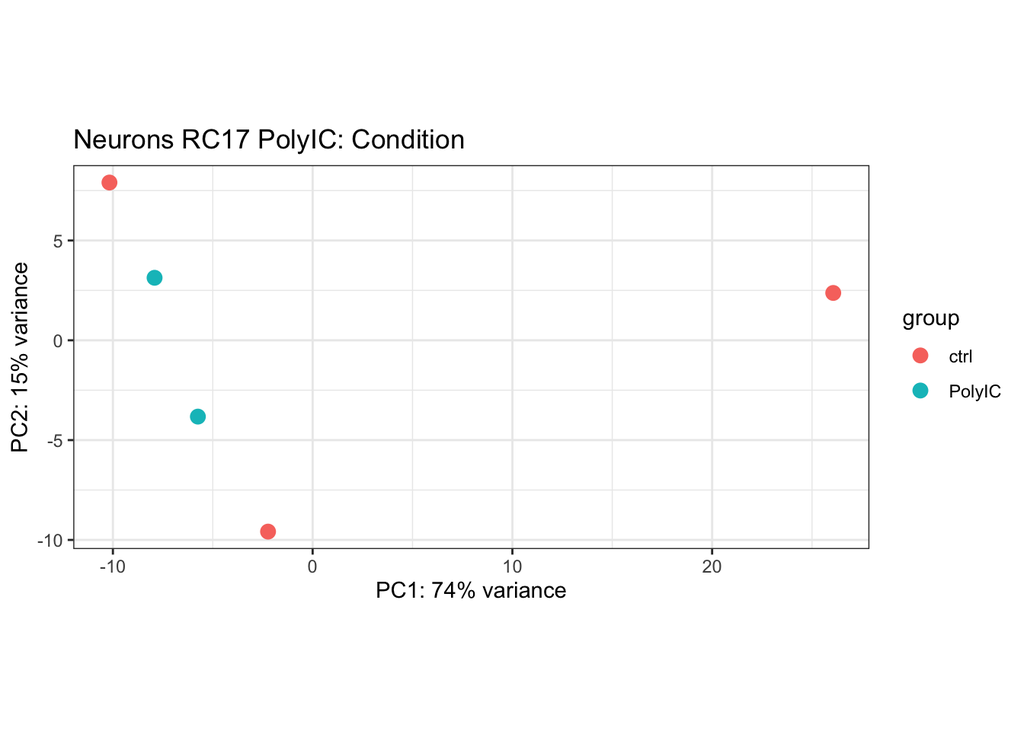

```r
plotPCA(gene_vst_list$neurons.RC17.PolyIC, intgroup="condition") + ggtitle("Neurons RC17 PolyIC: Condition") + theme_bw()
```

## Visualization

Mean plots, volcano plots and excel tables…

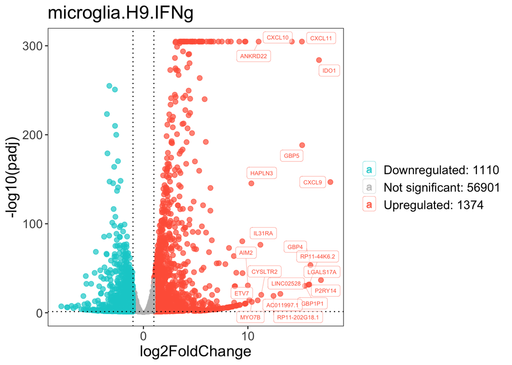

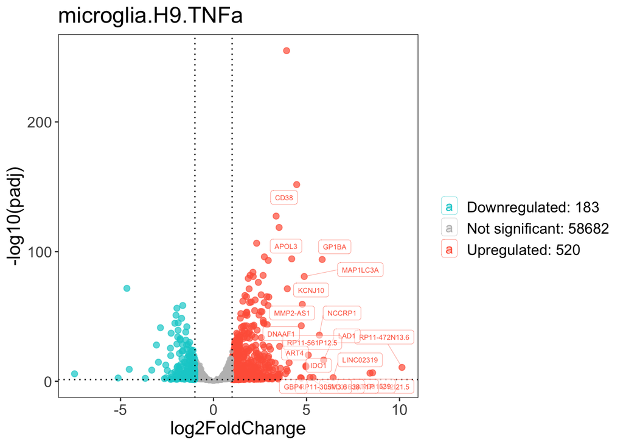

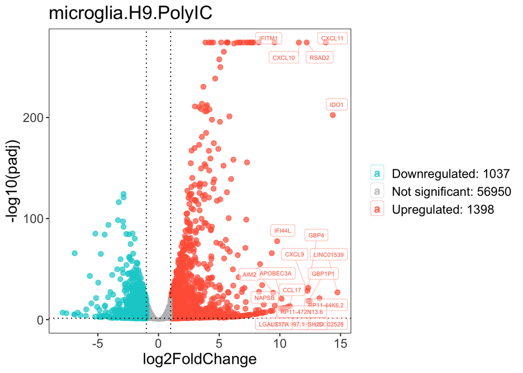

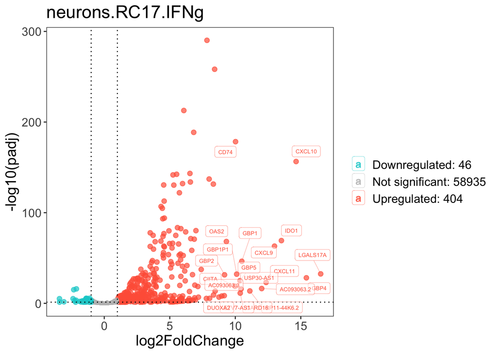

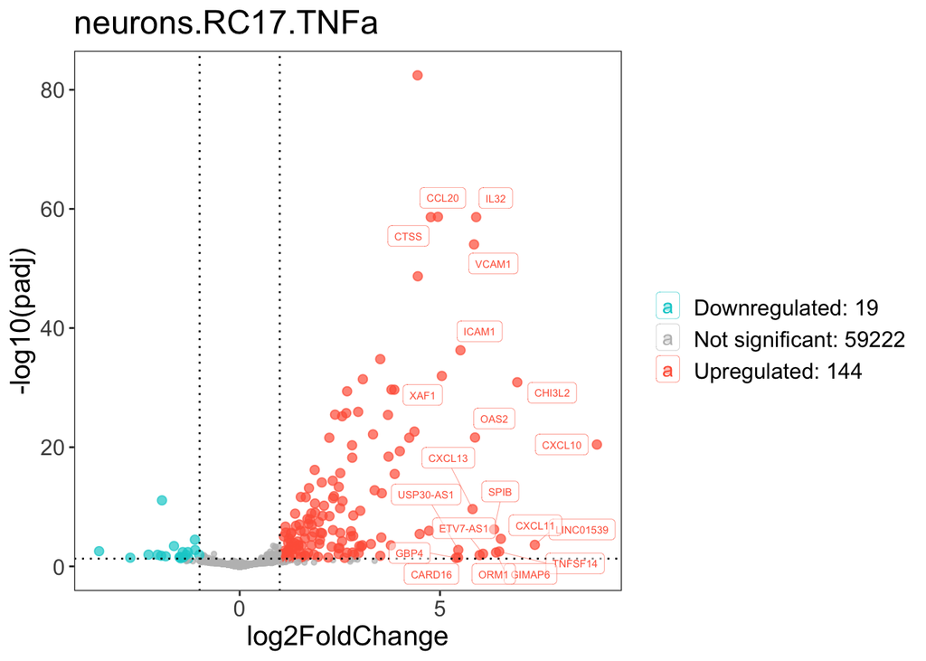

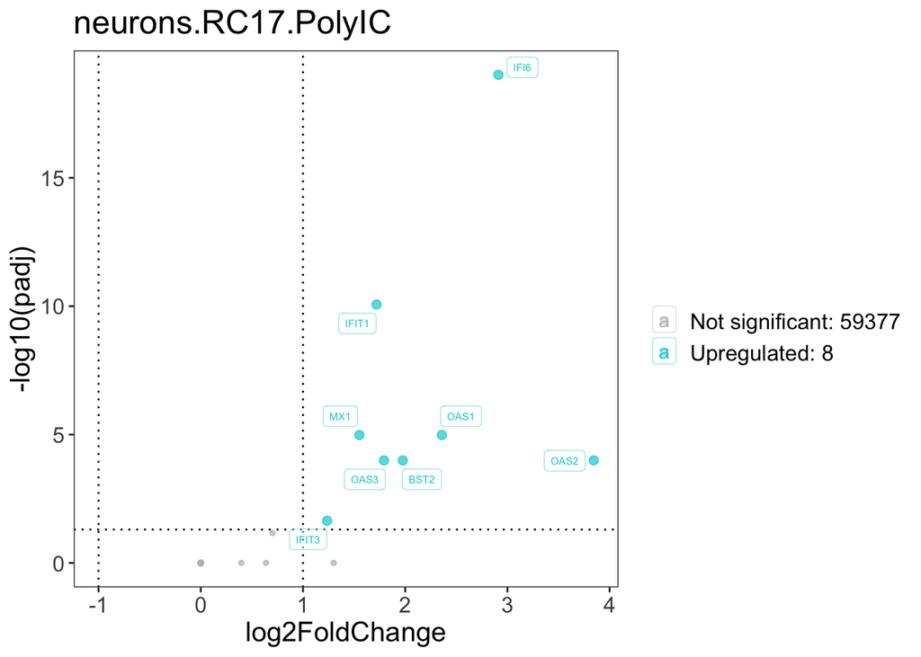

```r
# Write out the results from gene differential expression analysis
# openxlsx::write.xlsx(gene_res_list_df, file = "/Volumes/MyPassport/ASAP_invitro/results/tables/genes_DEA.xlsx")
# Create volcano and mean plots per experiment
volcano_plots_list <- list()
mean_plots_list <- list()
i <- "neurons.RC17.PolyIC"
for(i in names(gene_res_list)){
  tmp <- EnhancedVolcano(gene_res_list[[i]],
                                             drawConnectors = T,
                                             lab = NA,
                                             x = 'log2FoldChange',
                                             y = 'padj',
                                             pCutoff = 0.05,
                                             FCcutoff = 1)
  tmp$data$Sig <- ifelse(tmp$data$log2FoldChange > 1 & tmp$data$Sig == "FC_P", "Upregulated",
                                             ifelse(tmp$data$log2FoldChange < -1 & tmp$data$Sig == "FC_P", "Downregulated", "Not significant"))
  tmp$data$Sig <- paste(tmp$data$Sig, table(tmp$data$Sig)[tmp$data$Sig], sep = ": ")

  not_sig_lab <- unique(tmp$data$Sig)[startsWith(unique(tmp$data$Sig), "Not significant")]
  up_sig_lab <- unique(tmp$data$Sig)[startsWith(unique(tmp$data$Sig), "Upregulated")]
  down_sig_lab <- unique(tmp$data$Sig)[startsWith(unique(tmp$data$Sig), "Downregulated")]

  point_colours <- c("grey","darkturquoise", "tomato")
  names(point_colours) <- c(not_sig_lab, down_sig_lab, up_sig_lab)
  point_sizes <- c(1,2,2)
  names(point_sizes) <- c(not_sig_lab, down_sig_lab, up_sig_lab)

  title <- str_replace_all(i, pattern = "_", replacement = " ")

  tmp <- tmp$data
  tmp$gene_name <- rownames(tmp)
  tmp <- tmp[order(tmp$log2FoldChange, decreasing = T), ]
  tmp$gene_name <- ifelse(tmp$gene_name %in% tmp[which(startsWith(tmp$Sig, "Upregulated")),"gene_name"], tmp$gene_name, "")
  tmp$gene_name <- ifelse(tmp$gene_name %in% tmp[order(tmp$log2FoldChange, decreasing = T)[1:20],"gene_name"], tmp$gene_name, "")

  volcano_plots_list[[i]] <- ggplot(tmp, aes(x=log2FoldChange, y=-log10(padj), colour=Sig, size=Sig, label=gene_name)) + geom_point(alpha=0.7) +
    geom_vline(xintercept = 1, linetype="dotted") + geom_vline(xintercept = -1, linetype="dotted") +
    geom_hline(yintercept = -log10(0.05), linetype="dotted") + labs(colour="") +
    geom_label_repel(max.overlaps = 100, label.size = 0.1, segment.size = 0.1, fill = alpha(c("white"),0.5)) +
    scale_color_manual(values = point_colours)  +
    scale_size_manual(values = point_sizes, guide="none") +
    theme_bw() +
    theme(text = element_text(size=15), panel.grid.minor = element_blank(), panel.grid.major = element_blank()) +
    ggtitle(title)

  effect <- unique(samplesheet_list[[i]][which(samplesheet_list[[i]]$condition != "ctrl"),"condition"])
  mean_plots_list[[i]] <- meanPlot_cus(exp = gene_exp_list[[i]]$Mean,
                                       test = gene_res_list[[i]], #col1 = "tomato", col2 = "grey", col3 = "tomato",
                                       c1 = effect, c2="ctrl", p = 0.05, l=1, ttl = title, repel = F, highlights = tmp$gene_name)

}
# Order to plot
order <- c("microglia.H9.IFNg",
           "microglia.H9.TNFa",
           "microglia.H9.PolyIC",
           "neurons.RC17.IFNg",
           "neurons.RC17.TNFa",
           "neurons.RC17.PolyIC")

volcano_plots_list[order]
```

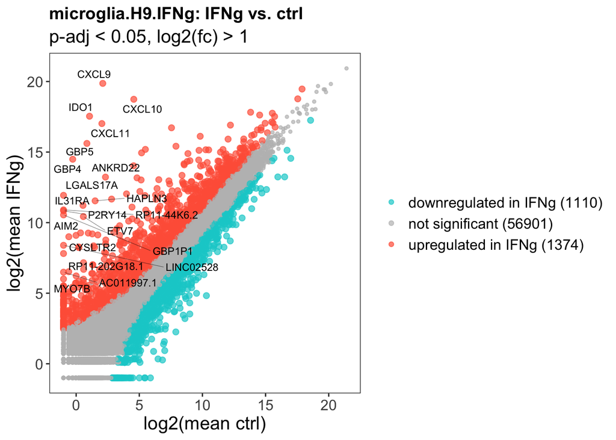

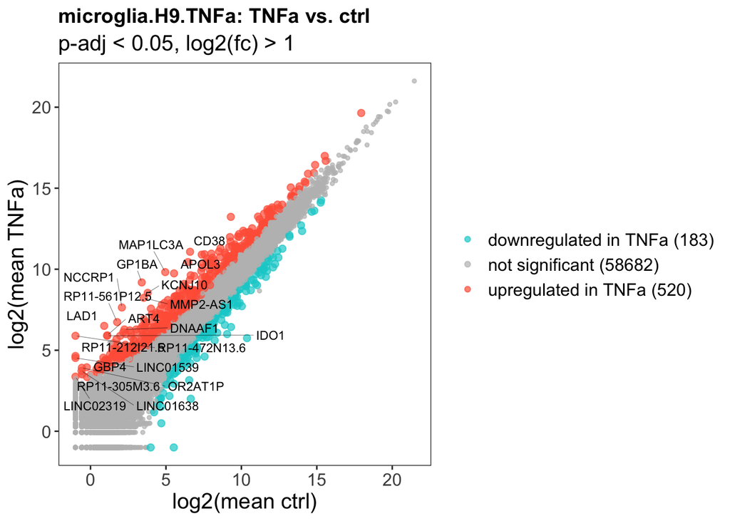

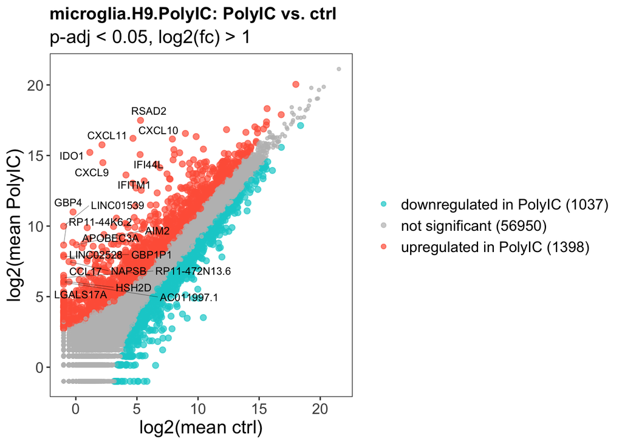

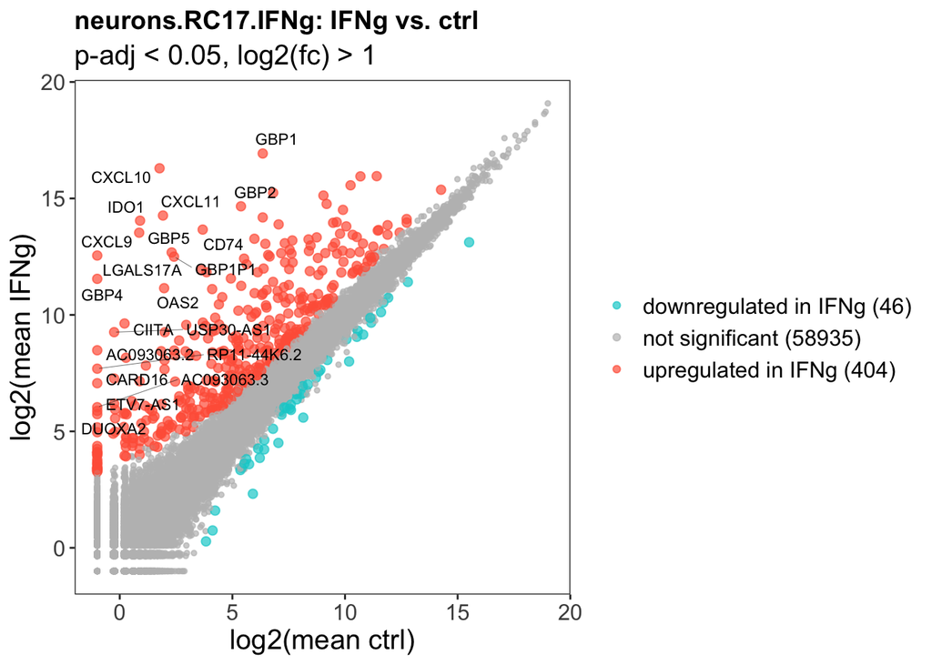

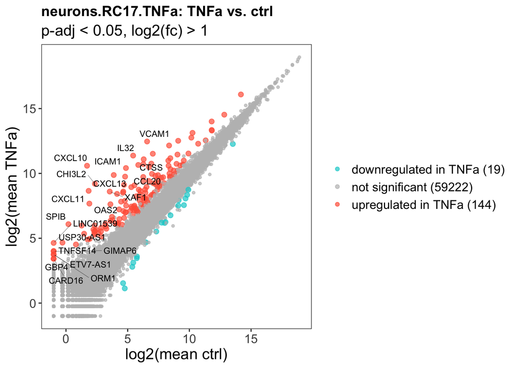

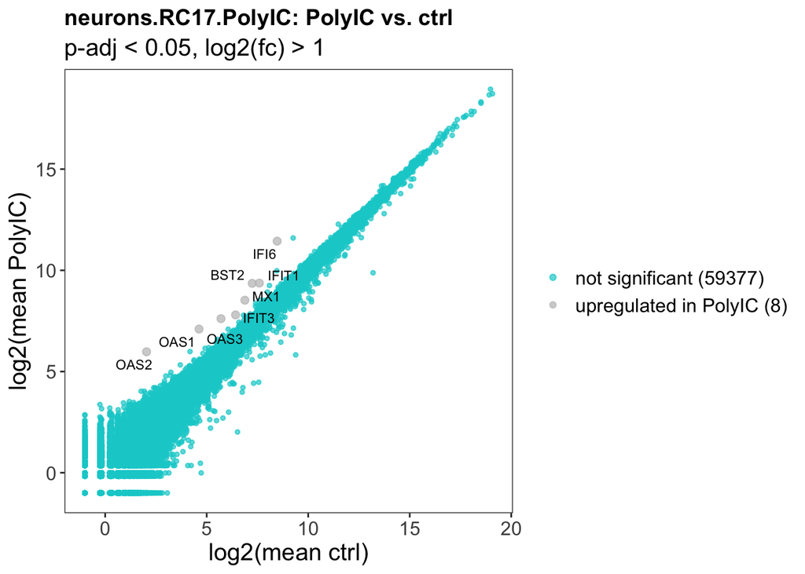

```r
mean_plots_list[order]
```